# Checkpoint1

Arthur Sena

04/06/2016

# Descriçao dos dados

Os dados são referentes aos usuários de ônibus de Curitiba, onde cada linha do arquivo segue o seguinte padrão:

```
##    VEIC       LAT       LON                DTHR COD_LINHA
## 1 AA005 -25.39843 -49.21191 20/10/2015 18:53:17       812
## 2 AA005 -25.39855 -49.21193 20/10/2015 18:43:16       812
## 3 AA005 -25.39845 -49.21203 20/10/2015 18:33:15       812
## 4 AA005 -25.39832 -49.21204 20/10/2015 18:23:14       812
## 5 AA005 -25.39860 -49.21202 20/10/2015 18:16:46       812
## 6 AA005 -25.39832 -49.21199 20/10/2015 18:11:12       812
```

As variáveis e seus significados estão listados abaixo:

**VEIC** - identificador do veículo **LAT** - coordenada latitude **LON** - coordenada longitude **DTHR** - data e hora da localização **COD_LINHA** - Código da linha de ônibus

# Problema

A partir dos dados fornecidos, vamos predizer a duração da viagem de ônibus e linhas a partir da localização dos veículos, considerando como ponto inicial o primeiro registro de localização. Assim sendo, vamos precisar criar mais duas colunas no nosso dataset original, onde elas vão representar a duração da viagem e a, respectiva distância.

A fim de calcular a distância percorrida, a fórmula de distância euclidiana será usada. Dessa forma, vamos usar a LAT e LON pra calcular a distância entre os pontos, e dessa forma achar a distância feita pelo ônibus/linha. Nesse caso, o ponto inicial será o primeiro registro de localização. Uma lógica semelhante será aplicada a fim de calcular o tempo gasto pelo ônibus/linha.

Outro ponto a se considerar é que o mais de um veículos pode estar rodando na mesma linha. Desse modo, precisamos agrupar linha e veiculo a fim de criar os nossos modelo.

# Derivando a coluna distância

```r
   veic_AA005_linha_222 <- filter(dados, VEIC =='AA005',COD_LINHA == 222)
   veic_AA005_linha_812 <- filter(dados, VEIC =='AA005',COD_LINHA == 812)

   veic_AA006_linha_812 <- filter(dados, VEIC =='AA006',COD_LINHA == 812)
   veic_AA006_linha_822 <- filter(dados, VEIC =='AA006',COD_LINHA == 822)

   veic_AA007_linha_812 <- filter(dados, VEIC =='AA007',COD_LINHA == 812)
   veic_AA007_linha_827 <- filter(dados, VEIC =='AA007',COD_LINHA == 827)

    criarDistancia <- function(dataset){
         dataset$Distancia <- NA

         for (i in 1:nrow(dataset)){
             if (i == 1){
               dataset[i,6] = 0
            }
            else{
                  #Usando a distância euclidiana abaixo
                    dataset[i,6] = dataset[i-1,6] + sqrt((dataset[i,2] - dataset[i-1,2])^2 + (dataset[i,3] - dataset[i-1,3])^2)
            }
         }

         return(dataset)
    }

   veic_AA005_linha_222 <- criarDistancia(veic_AA005_linha_222)
   veic_AA005_linha_812 <- criarDistancia(veic_AA005_linha_812)

   veic_AA006_linha_812 <- criarDistancia(veic_AA006_linha_812)
   veic_AA006_linha_822  <- criarDistancia(veic_AA006_linha_822)

   veic_AA007_linha_812 <- criarDistancia(veic_AA007_linha_812)
   veic_AA007_linha_827 <- criarDistancia(veic_AA007_linha_827)
```

# Derivando a coluna tempo

```r
   criarDuracao <- function(dataset){
     #Criando o timestamp a partir da variável DTHR
     dataset$timestamp <- as.POSIXct(strptime(x = as.character(dataset$DTHR),
                                 format = "%d/%m/%Y %H:%M:%S"))
     dataset$Duracao <- NA
     temp_veic <- ""

     for (i in 1:nrow(dataset)){
         if (i == 1){
           dataset[i,8] = 0
        }
        else{
            #Subtraímos o tempo atual pelo anterior e somamos com o tempo até o ponto inicial
            dataset[i,8] = dataset[i-1,8] + (dataset[i-1,7]-dataset[i,7])
        }
     }
     return(dataset)
   }
   veic_AA005_linha_222 <- criarDuracao(veic_AA005_linha_222)
   veic_AA005_linha_812 <- criarDuracao(veic_AA005_linha_812)

   veic_AA006_linha_812 <- criarDuracao(veic_AA006_linha_812)
   veic_AA006_linha_822  <- criarDuracao(veic_AA006_linha_822)

   veic_AA007_linha_812 <- criarDuracao(veic_AA007_linha_812)
   veic_AA007_linha_827 <- criarDuracao(veic_AA007_linha_827)

    write.table(veic_AA005_linha_222, file="veic_AA005_linha_222.txt", sep = '\t')
    write.table(veic_AA005_linha_812, file="veic_AA005_linha_812.txt", sep = '\t')

    write.table(veic_AA006_linha_812, file="veic_AA006_linha_812.txt", sep = '\t')
    write.table(veic_AA006_linha_822, file="veic_AA006_linha_822.txt", sep = '\t')

    write.table(veic_AA007_linha_812, file="veic_AA007_linha_812.txt", sep = '\t')
    write.table(veic_AA007_linha_827, file="veic_AA007_linha_827.txt", sep = '\t')
```

Vamos agora analisar a distribuição da coluna ‘Duração’

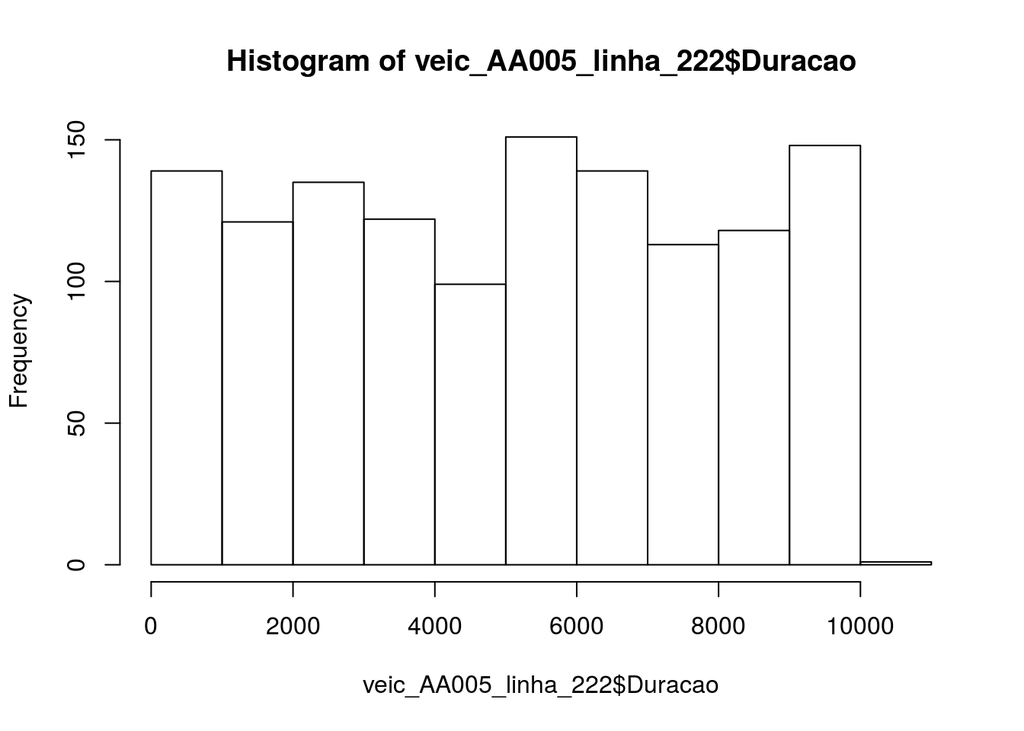

```r
    hist(veic_AA005_linha_222$Duracao)
```

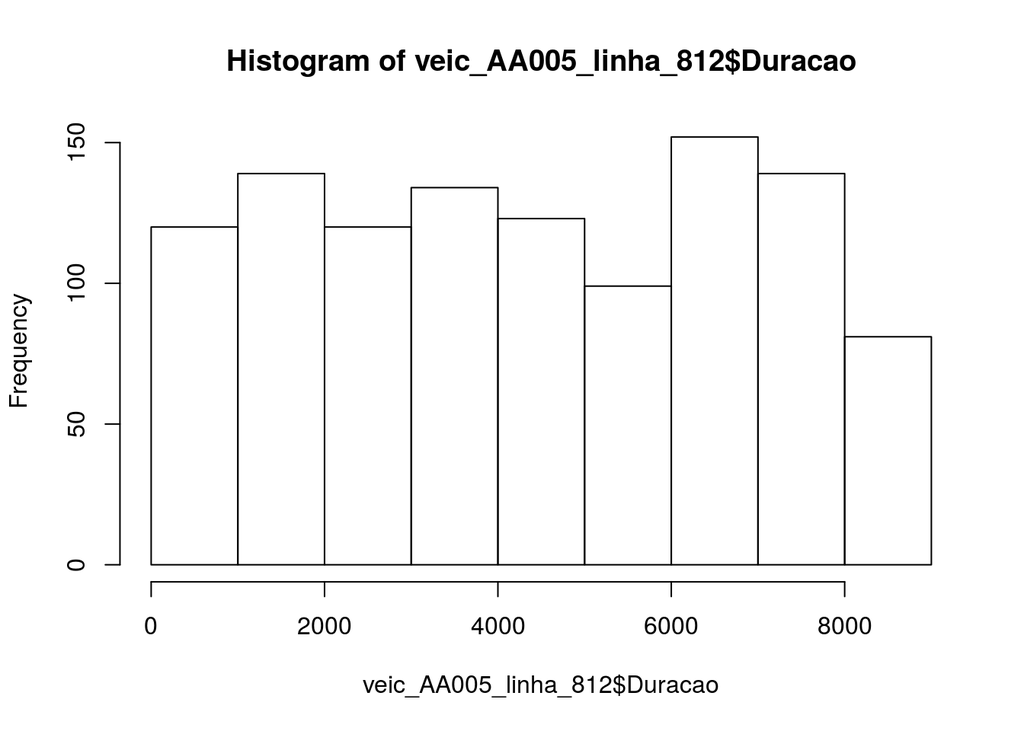

```r
    hist(veic_AA005_linha_812$Duracao)
```

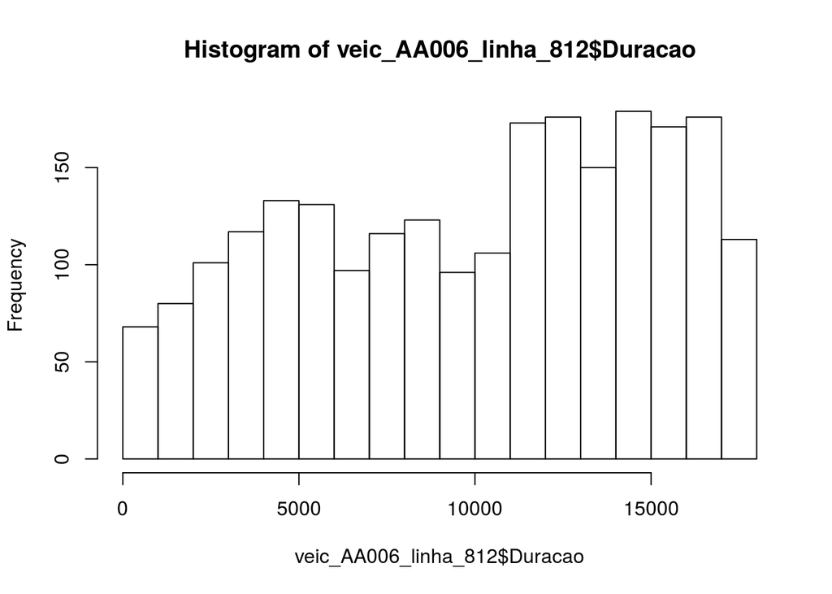

```r
    hist(veic_AA006_linha_812$Duracao)
```

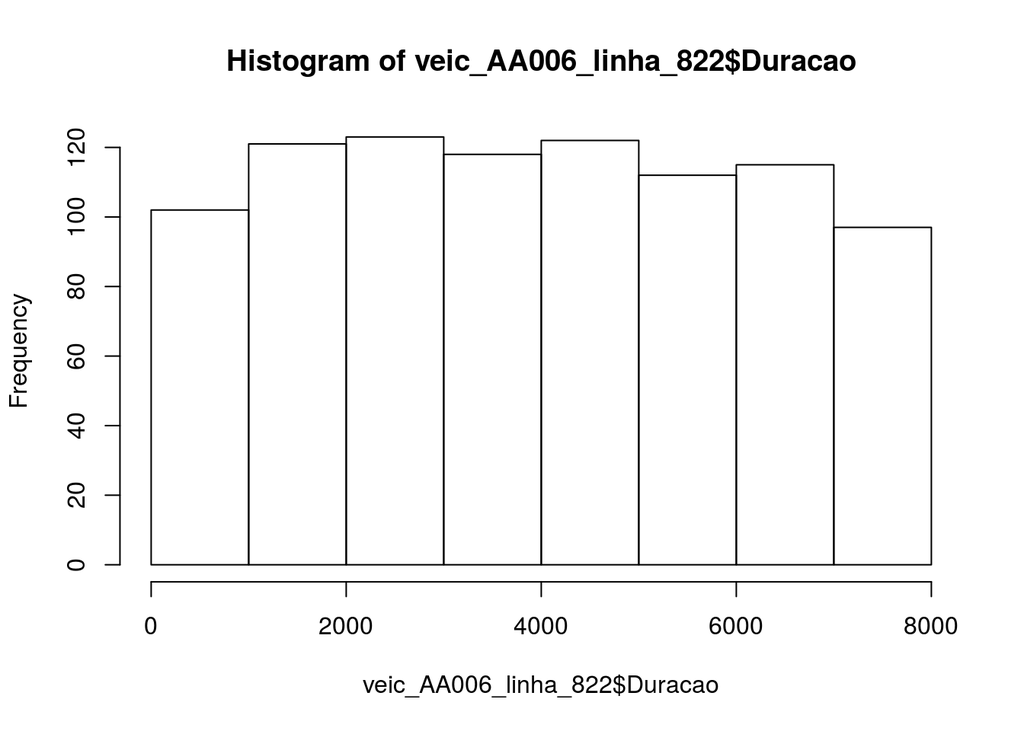

```r
    hist(veic_AA006_linha_822$Duracao)
```

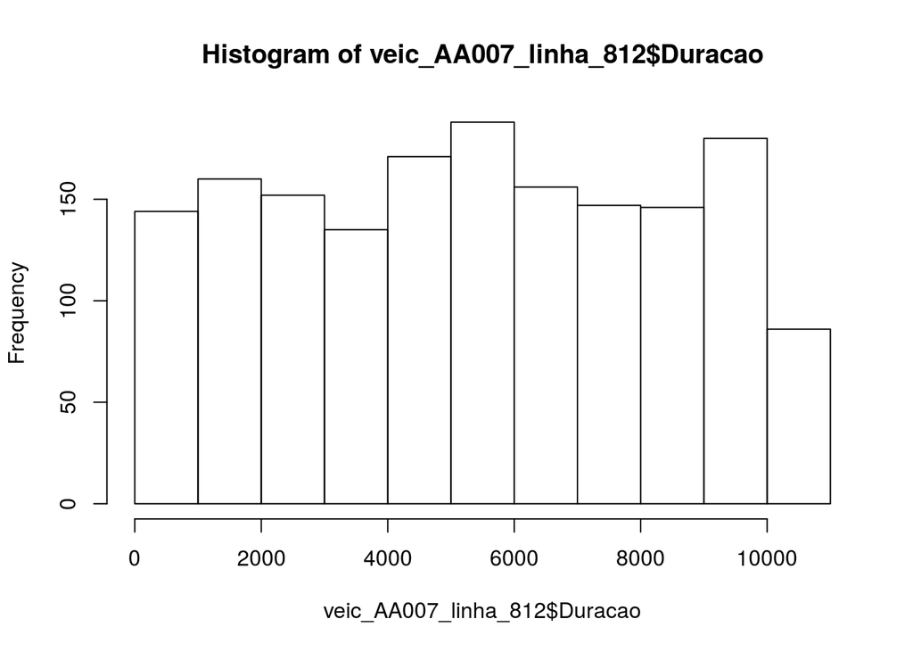

```r
    hist(veic_AA007_linha_812$Duracao)
```

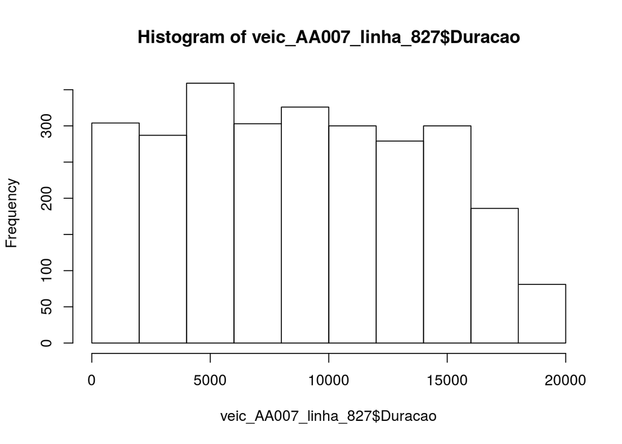

```r
    hist(veic_AA007_linha_827$Duracao)
```

Aparentemente, nossos dados apresentam uma distribuição sem nenhum outlier’s perceptível.

Vamos analisar a correlação entre as variáveis distância e duração.

```r
    cor(veic_AA005_linha_222$Duracao, veic_AA005_linha_222$Distancia)
```

```
## [1] 0.9988236
```

```r
    cor(veic_AA005_linha_812$Duracao, veic_AA005_linha_812$Distancia)
```

```
## [1] 0.9988399
```

```r
    cor(veic_AA006_linha_812$Duracao,veic_AA006_linha_812$Distancia)
```

```
## [1] 0.9969201
```

```r
    cor(veic_AA006_linha_822$Duracao,veic_AA006_linha_822$Distancia)
```

```
## [1] 0.9995893
```

```r
    cor(veic_AA007_linha_812$Duracao,veic_AA007_linha_812$Distancia)
```

```
## [1] 0.9996844
```

```r
    cor(veic_AA007_linha_827$Duracao,veic_AA007_linha_827$Distancia)
```

```
## [1] 0.9987357
```

Vemos que temos uma correlação muito alta entre as duas variáveis. Ou seja, a distância é uma ótima preditora para a duração da viagem.

# Criando os modelos

Vamos usar o ‘Caret’ para dividir em treino e teste o dataset e criar os modelos. No caso, vamos criar um modelo pra cada veiculo. Cada um desses modelos irá tentar prever a duração da viagem do seu, respectivo, veículo.

```r
    library(caret)

   #Criando as partições de treino e teste
    index_AA005_linha_222 <- createDataPartition(veic_AA005_linha_222$Duracao, p = .75, list = FALSE)

    index_AA005_linha_812 <- createDataPartition(veic_AA005_linha_812$Duracao, p = .75, list = FALSE)

    index_AA006_linha_812 <- createDataPartition(veic_AA006_linha_812$Duracao, p = .75, list = FALSE)

    index_AA006_linha_822 <- createDataPartition(veic_AA006_linha_822$Duracao, p = .75, list = FALSE)

    index_AA007_linha_812 <- createDataPartition(veic_AA007_linha_812$Duracao, p = .75, list = FALSE)

    index_AA007_linha_827 <- createDataPartition(veic_AA007_linha_827$Duracao, p = .75, list = FALSE)

    training_AA005_linha_222 <- veic_AA005_linha_222[ index_AA005_linha_222,]
    testing_AA005_linha_222  <- veic_AA005_linha_222[-index_AA005_linha_222,]

    training_AA005_linha_812 <- veic_AA005_linha_812[ index_AA005_linha_812,]
    testing_AA005_linha_812  <- veic_AA005_linha_812[-index_AA005_linha_812,]

    training_AA006_linha_812 <- veic_AA006_linha_812[ index_AA006_linha_812,]
    testing_AA006_linha_812  <- veic_AA006_linha_812[-index_AA006_linha_812,]

    training_AA006_linha_822 <- veic_AA006_linha_822[ index_AA006_linha_822,]
    testing_AA006_linha_822  <- veic_AA006_linha_822[-index_AA006_linha_822,]

    training_AA007_linha_812 <- veic_AA007_linha_812[ index_AA007_linha_812,]
    testing_AA007_linha_812  <- veic_AA007_linha_812[-index_AA007_linha_812,]

    training_AA007_linha_827 <- veic_AA007_linha_827[ index_AA007_linha_827,]
    testing_AA007_linha_827  <- veic_AA007_linha_827[-index_AA007_linha_827,]

   #Usando cross-validation para evitar o overfitting
    fitControl <- trainControl(
                           method = "repeatedcv",
                           number = 10,
                           repeats = 10)

   #Treinando os modelos usando regressão linear
    mode_AA005_linha_222 <- train(Duracao ~ Distancia, data = training_AA005_linha_222,
                 method = "lm",
                 metric = "RMSE",
                 trControl = fitControl)

    mode_AA005_linha_812 <- train(Duracao ~ Distancia, data = training_AA005_linha_812,
                 method = "lm",
                 metric = "RMSE",
                 trControl = fitControl)

    mode_AA006_linha_812 <- train(Duracao ~ Distancia, data = select(training_AA006_linha_812,Duracao, Distancia),
                 method = "lm",
                 metric = "RMSE",
                 trControl = fitControl)

  mode_AA006_linha_822 <- train(Duracao ~ Distancia, data = training_AA006_linha_822,
                 method = "lm",
                 metric = "RMSE",
                 trControl = fitControl)

    mode_AA007_linha_812 <- train(Duracao ~ Distancia, data = training_AA007_linha_812,
                 method = "lm",
                 metric = "RMSE",
                 trControl = fitControl)

    mode_AA007_linha_827<- train(Duracao ~ Distancia, data = training_AA007_linha_827,
                 method = "lm",
                 metric = "RMSE",
                 trControl = fitControl)

    print(mode_AA005_linha_222)
```

```
## Linear Regression
##
## 966 samples
##   7 predictors
##
## No pre-processing
## Resampling: Cross-Validated (10 fold, repeated 10 times)
##
## Summary of sample sizes: 868, 869, 870, 869, 869, 870, ...
##
## Resampling results
##
##   RMSE     Rsquared   RMSE SD   Rsquared SD
##   139.988  0.9977102  9.501542  0.0003157854
##
##
```

```r
    print(mode_AA005_linha_812)
```

```
## Linear Regression
##
## 831 samples
##   7 predictors
##
## No pre-processing
## Resampling: Cross-Validated (10 fold, repeated 10 times)
##
## Summary of sample sizes: 749, 747, 748, 747, 747, 749, ...
##
## Resampling results
##
##   RMSE      Rsquared   RMSE SD  Rsquared SD
##   121.4355  0.9976828  7.85597  0.0003047844
##
##
```

```r
    print(mode_AA006_linha_812)
```

```
## Linear Regression
##
## 1730 samples
##    1 predictors
##
## No pre-processing
## Resampling: Cross-Validated (10 fold, repeated 10 times)
##
## Summary of sample sizes: 1555, 1558, 1557, 1557, 1558, 1556, ...
##
## Resampling results
##
##   RMSE      Rsquared   RMSE SD   Rsquared SD
##   390.5824  0.9939023  17.24283  0.0006062945
##
##
```

```r
    print(mode_AA006_linha_822)
```

```
## Linear Regression
##
## 684 samples
##   7 predictors
##
## No pre-processing
## Resampling: Cross-Validated (10 fold, repeated 10 times)
##
## Summary of sample sizes: 616, 616, 616, 616, 615, 616, ...
##
## Resampling results
##
##   RMSE      Rsquared   RMSE SD  Rsquared SD
##   64.84726  0.9991724  3.93476  0.0001070329
##
##
```

```r
    print(mode_AA007_linha_812)
```

```
## Linear Regression
##
## 1249 samples
##    7 predictors
##
## No pre-processing
## Resampling: Cross-Validated (10 fold, repeated 10 times)
##
## Summary of sample sizes: 1124, 1123, 1124, 1124, 1125, 1123, ...
##
## Resampling results
##
##   RMSE      Rsquared   RMSE SD  Rsquared SD
##   75.67627  0.9993738  3.43069  7.390104e-05
##
##
```

```r
    print(mode_AA007_linha_827)
```

```
## Linear Regression
##
## 2045 samples
##    7 predictors
##
## No pre-processing
## Resampling: Cross-Validated (10 fold, repeated 10 times)
##
## Summary of sample sizes: 1841, 1840, 1840, 1841, 1841, 1840, ...
##
## Resampling results
##
##   RMSE      Rsquared   RMSE SD   Rsquared SD
##   263.6116  0.9974304  17.78455  0.0002872637
##
##
```

Conseguimos um bom R2 no treino. Agora, vamos ver como os modelos se comportam no teste.

# Testando os modelos

Vamos agora testar nossosm modelos e calcular o R2 e RMSE pra cada um.

```r
    predicoes_AA005_linha_222 <- predict(mode_AA005_linha_222, select(testing_AA005_linha_222, Distancia))
    predicoes_AA005_linha_812 <- predict(mode_AA005_linha_812, select(testing_AA005_linha_812, Distancia))

    predicoes_AA006_linha_812 <- predict(mode_AA006_linha_812, select(testing_AA006_linha_812, Distancia))
    predicoes_AA006_linha_822 <- predict(mode_AA006_linha_822, select(testing_AA006_linha_822, Distancia))

    predicoes_AA007_linha_812 <- predict(mode_AA007_linha_812, select(testing_AA007_linha_812, Distancia))
    predicoes_AA007_linha_827 <- predict(mode_AA007_linha_827, select(testing_AA007_linha_827, Distancia))

    residuos_AA005_linha_222 <- testing_AA005_linha_222$Duracao - predicoes_AA005_linha_222
    residuos_AA005_linha_812 <- testing_AA005_linha_812$Duracao - predicoes_AA005_linha_812

    residuos_AA006_linha_812 <- testing_AA006_linha_812$Duracao - predicoes_AA006_linha_812
    residuos_AA006_linha_822 <- testing_AA006_linha_822$Duracao - predicoes_AA006_linha_822

    residuos_AA007_linha_812 <- testing_AA007_linha_812$Duracao - predicoes_AA007_linha_812
    residuos_AA007_linha_827 <- testing_AA007_linha_827$Duracao - predicoes_AA007_linha_827

   r2_AA005_linha_222 <- R2(predicoes_AA005_linha_222, testing_AA005_linha_222$Duracao)
   r2_AA005_linha_812 <- R2(predicoes_AA005_linha_812, testing_AA005_linha_812$Duracao)

   r2_AA006_linha_812 <- R2(predicoes_AA006_linha_812, testing_AA006_linha_812$Duracao)
   r2_AA006_linha_822 <- R2(predicoes_AA006_linha_822, testing_AA006_linha_822$Duracao)

   r2_AA007_linha_812 <- R2(predicoes_AA007_linha_812, testing_AA007_linha_812$Duracao)
   r2_AA007_linha_827 <- R2(predicoes_AA007_linha_827, testing_AA007_linha_827$Duracao)

   rmse_AA005_linha_222 <- RMSE(predicoes_AA005_linha_222, testing_AA005_linha_222$Duracao)
   rmse_AA005_linha_812 <- RMSE(predicoes_AA005_linha_812, testing_AA005_linha_812$Duracao)

   rmse_AA006_linha_812 <- RMSE(predicoes_AA006_linha_812, testing_AA006_linha_812$Duracao)
   rmse_AA006_linha_822 <- RMSE(predicoes_AA006_linha_822, testing_AA006_linha_822$Duracao)

   rmse_AA007_linha_812 <- RMSE(predicoes_AA007_linha_812, testing_AA007_linha_812$Duracao)
   rmse_AA007_linha_827 <- RMSE(predicoes_AA007_linha_827, testing_AA007_linha_827$Duracao)

   r2_AA005_linha_222
```

```
## [1] 0.9975548
```

```r
   r2_AA005_linha_812
```

```
## [1] 0.997797
```

```r
   r2_AA006_linha_812
```

```
## [1] 0.9937142
```

```r
   r2_AA006_linha_822
```

```
## [1] 0.9992212
```

```r
   r2_AA007_linha_812
```

```
## [1] 0.9993702
```

```r
   r2_AA007_linha_827
```

```
## [1] 0.9976838
```

Vemos que apresentamos um R2 bem alto, o que indica que os nossos modelos conseguem explicar uma alta porcentagem da variação da nossa variável alvo. Isso, também, indica que todos os veículose linhas são bastante previsiveís. Podemos agora mostrar os gráficos entre as nossas predições e o valor real.

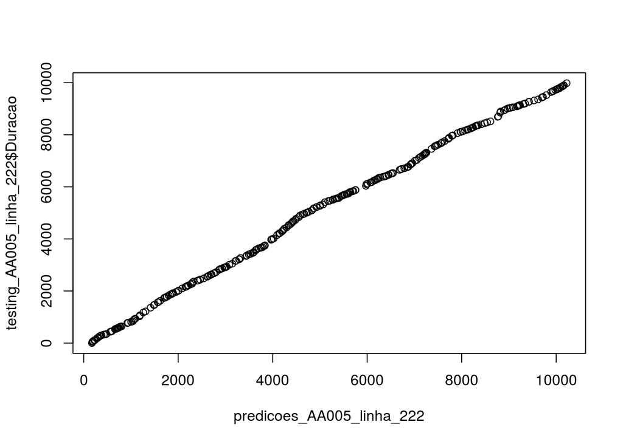

```r
          plot(predicoes_AA005_linha_222, testing_AA005_linha_222$Duracao)
```

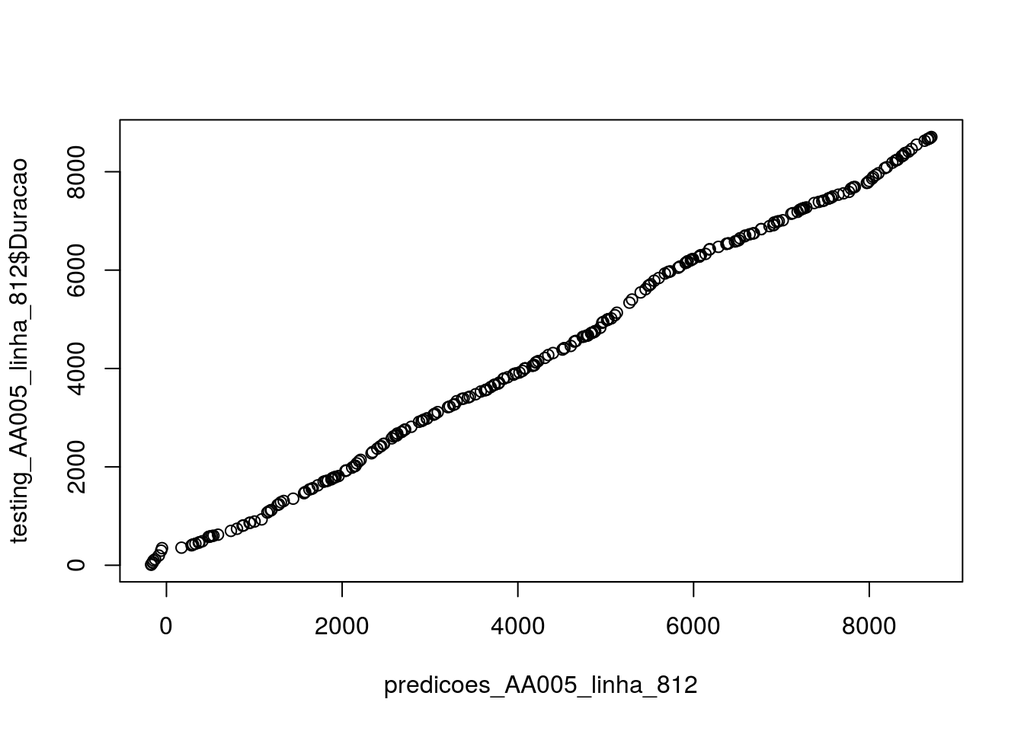

```r
          plot(predicoes_AA005_linha_812, testing_AA005_linha_812$Duracao)
```

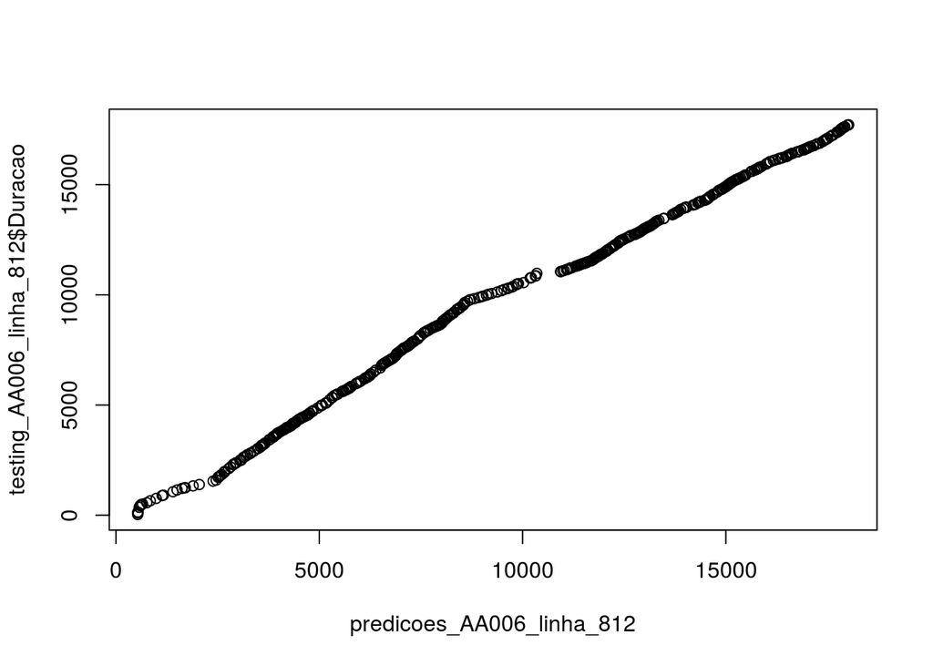

```r
          plot(predicoes_AA006_linha_812, testing_AA006_linha_812$Duracao)
```

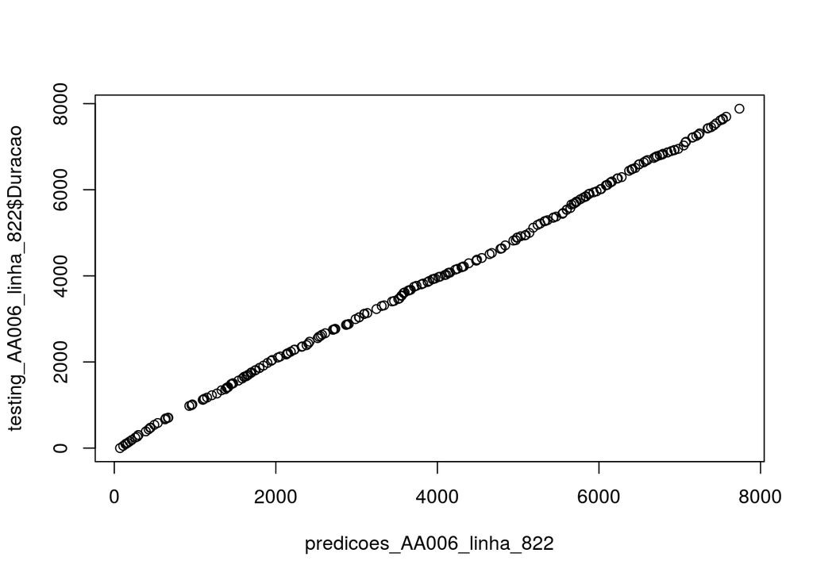

```r
          plot(predicoes_AA006_linha_822, testing_AA006_linha_822$Duracao)
```

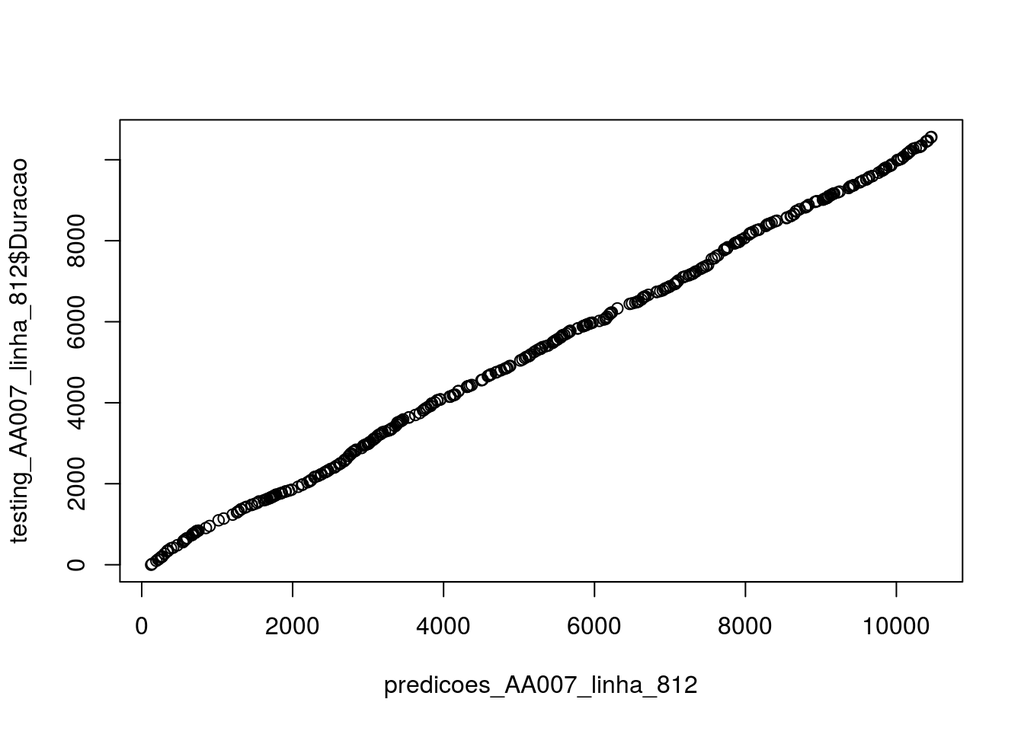

```r
          plot(predicoes_AA007_linha_812, testing_AA007_linha_812$Duracao)
```

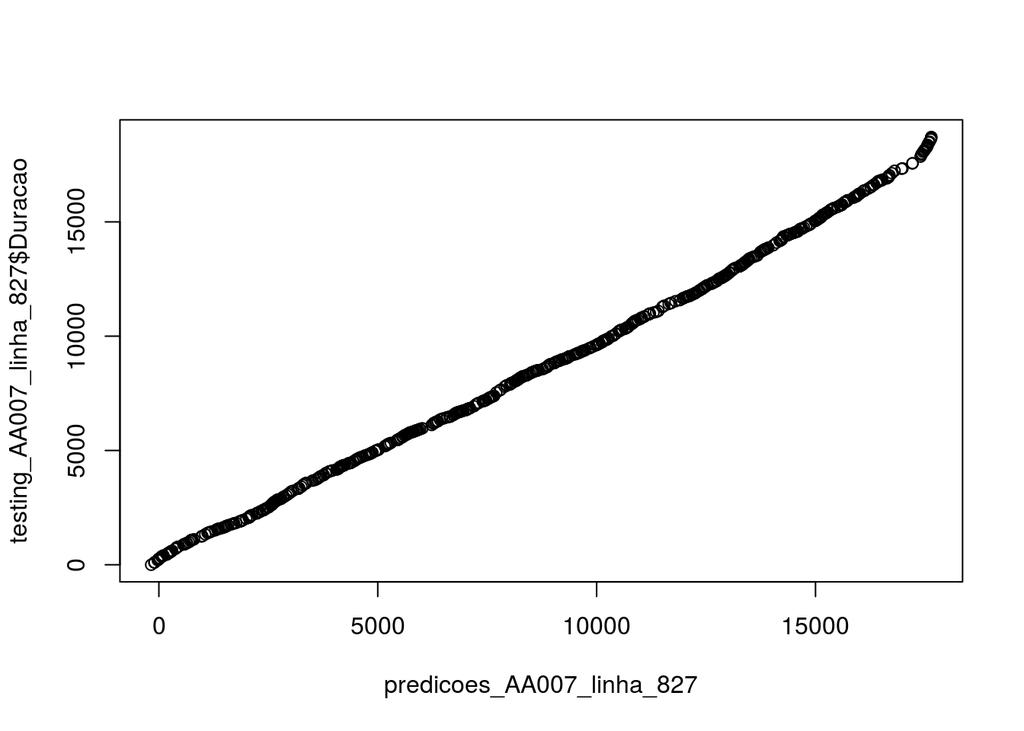

```r
          plot(predicoes_AA007_linha_827, testing_AA007_linha_827$Duracao)
```

Observando os gráficos acima, vemos claramente que existe uma relação linear forte entre nossas predições e os valores reais.

# Conclusão

Podemos concluir que todas as linhas e veículos são facilmente previsíveis, pois existe uma correlação muito forte entre a distância percorrida e o tempo gasto.